# Tvyal Newsletter

Aghasi Tavadyan

2024-07-05

*English summary below.*

Հարգելի գործընկեր,

Հուսով եմ՝ լավ եք: Ներկայացնում եմ այս շաբաթվա վերլուծությունները և աշխատանքները.

## [🇷🇺💰🇦🇲 Հայաստան` ռուսական ոսկու հանգրվան](https://www.tvyal.com/newsletter/2024/2024_07_05)

### **2024 թվականին Ռուսաստանի ոսկու արտահանման 88 տոկոսն անցել է Հայաստանով**

### Ներածություն

Վերջին տարիներին համաշխարհային ոսկու առևտրում տեղի են ունեցել նշանակալի փոփոխություններ, որոնց արդյունքում Հայաստանը դարձել է Ռուսաստանի ոսկու արտահանման վերաբաշխման կարևոր դերակատար: Այս փոխակերպումը մեծապես պայմանավորված է 2022 թվականին տեղի ունեցած աշխարհաքաղաքական փոփոխություններով, մասնավորապես՝ Ուկրաինայում Ռուսաստանի ռազմական գործողություններին հաջորդած պատժամիջոցներով: Այս վերլուծությունը ուսումնասիրում է Ռուսաստանի և Հայաստանի ոսկու առևտրի զարգացող դինամիկան՝ օգտագործելով պաշտոնական տվյալների և հայելային վիճակագրության հիման վրա գնահատված կառուցված մեթոդաբանություն:

### Մաս 1. Ռուսաստանի ոսկու արտահանման օրինաչափությունները

Մինչև 2022 թվականը Ռուսաստանի ոսկու արտահանման օրինաչափությունները համեմատաբար կայուն և կանխատեսելի էին: Ինչպես ցույց է տրված առաջին գծապատկերում, 2019-ից 2021 թվականներին Ռուսաստանի ոսկին հիմնականում արտահանվում էր Միացյալ Թագավորությունը: 2019 թվականին Ռուսաստանի ոսկու (ԱՏԳ ԱԱ ծածկագիր 7108՝ Ոսկի անմշակ կամ կիսամշակ, փոշի) 91,5%-ը արտահանվել է Միացյալ Թագավորություն: Այս միտումը շարունակվել է 2020 և 2021 թվականներին՝ համապատասխանաբար 90,8% և 88,1% արտահանմամբ դեպի Միացյալ Թագավորություն:

**Գծապատկեր 1.**

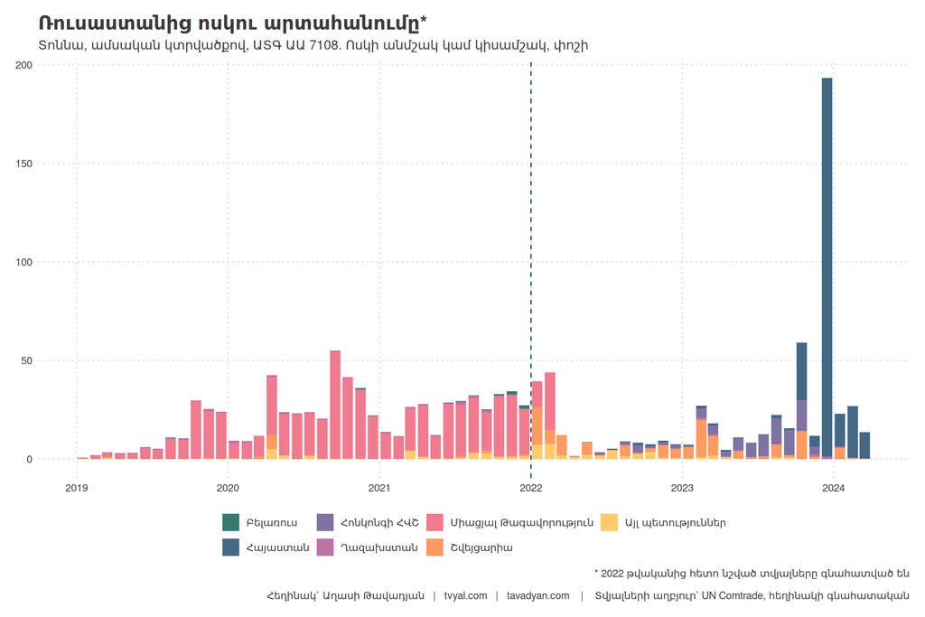

Այնուամենայնիվ, 2022 թվականին իրավիճակը կտրուկ փոխվեց: Ռուսաստանի դեմ կիրառված պատժամիջոցները հանգեցրին ոսկու արտահանման ուղղությունների արագ դիվերսիֆիկացման: Միացյալ Թագավորություն արտահանման կտրուկ անկում է գրանցվել՝ զուգորդված նոր նշանակալի գործընկերների, այդ թվում՝ Հայաստանի ի հայտ գալով:

Փոխակերպումն ավելի ակնհայտ է դառնում, երբ դիտարկում ենք տարեկան տվյալները, ինչպես ներկայացված է երկրորդ գծապատկերում: 2022 թվականին Ռուսաստանի ոսկու արտահանման մասնատում մի քանի երկրների միջև, որտեղ Շվեյցարիան դարձել է խոշորագույն ներմուծողը (41,0%), որին հաջորդում է Միացյալ Թագավորությունը (27,3%) և այլ երկրներ:

**Գծապատկեր 2.**

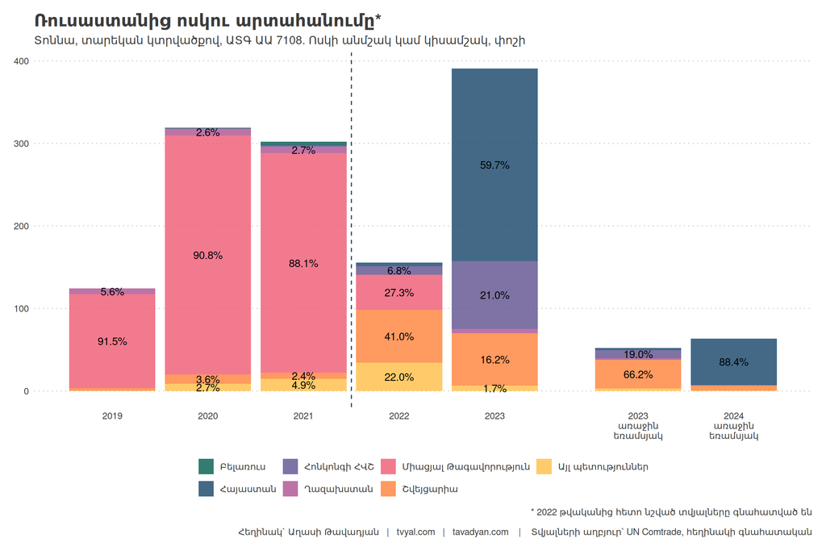

Ամենաուշագրավ զարգացումը տեղի ունեցավ 2023 թվականին և շարունակվեց 2024 թվականին: Հայաստանը, որը նախկինում երկրորդական դերակատար էր Ռուսաստանի ոսկու արտահանման մեջ, հանկարծակի դարձավ գերակշռող ուղղություն: 2023 թվականին Ռուսաստանի ոսկու արտահանման 59,7%-ն ուղղվեց Հայաստան: Այս միտումն ուժեղացավ 2024 թվականի առաջին եռամսյակում, երբ Ռուսաստանի ոսկու արտահանման զգալի 88,4%-ն անցավ Հայաստանով:

### Մաս 2. Հայաստանի ոսկու վերաարտահանում. Հանկարծակի աճ

Հայաստան ոսկու արտահանման այս աճը զուգադիպում է Հայաստանի ընդհանուր արտահանման ցուցանիշների դրամատիկ աճի հետ: [Ինչպես նշված է մեր նախորդ վերլուծության մեջ](https://www.tvyal.com/newsletter/2024/2024_04_12), Հայաստանի ընդհանուր արտահանումն աճել է էքսպոնենցիալ կերպով.

- 2021թ.՝ 3 միլիարդ ԱՄՆ դոլար
- 2022թ.՝ 5,4 միլիարդ ԱՄՆ դոլար
- 2023թ.՝ 8,4 միլիարդ ԱՄՆ դոլար
- 2024թ. (կանխատեսում)՝ մոտ 18 միլիարդ ԱՄՆ դոլար

Այնուամենայնիվ, կարևոր է հասկանալ, որ այս աճը հիմնականում պայմանավորված է ոսկու վերաարտահանմամբ: Փաստացի, 2024 թվականի առաջին չորս ամիսներին Հայաստանի արտահանման մոտ 76%-ը կազմել է թանկարժեք և կիսաթանկարժեք քարերի և մետաղների վերաարտահանումը՝ հիմնականում դեպի Արաբական Միացյալ Էմիրություններ, Հոնկոնգ և Չինաստան:

**Գծապատկեր 3.**

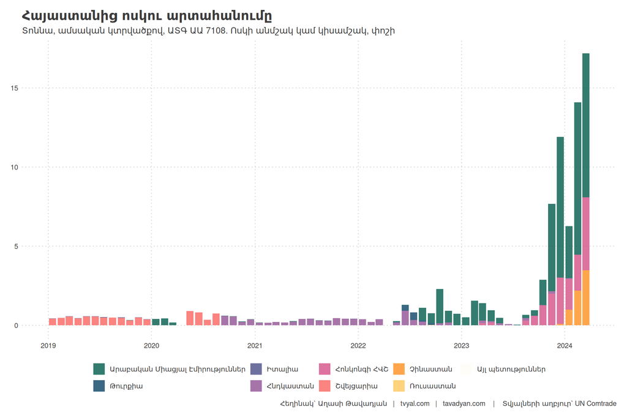

Երրորդ գծապատկերը ցույց է տալիս Հայաստանի ոսկու արտահանման օրինաչափությունների դրամատիկ փոփոխությունը: Տվյալները ցույց են տալիս կտրուկ աճ՝ սկսած 2023 թվականի վերջից, արտահանման ծավալները հասել են աննախադեպ մակարդակների 2024 թվականի սկզբին: Այս ամսական բաշխվածությունը բացահայտում է Հայաստանի դերի արագ փոփոխությանը միջազգային ոսկու առևտրում:

**Գծապատկեր 4.**

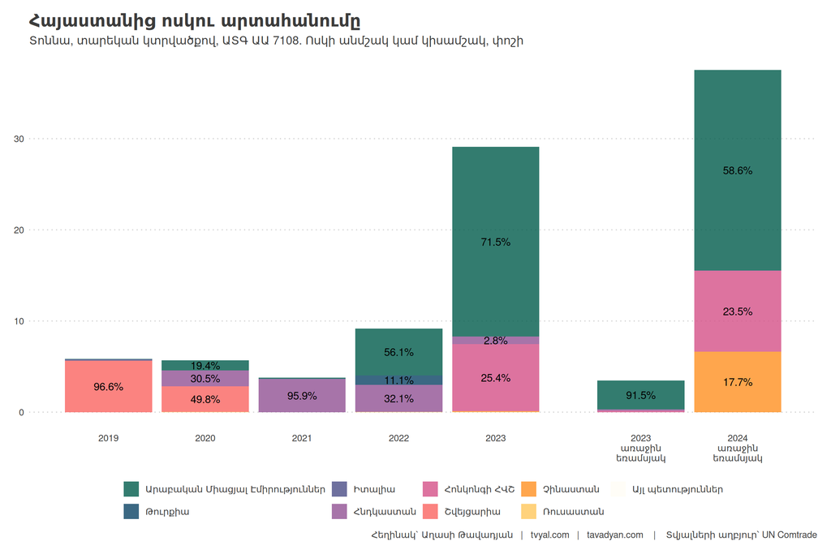

Փոփոխությունը ակնհայտ է։ Եթե 2019 թվականին Շվեյցարիան Հայաստանի ոսկու արտահանման հիմնական ուղղությունն էր (արտահանման 96,6%-ը), ապա 2023 թվականին Արաբական Միացյալ Էմիրություններն են դարձել գերակշռող ստացողը (71,5%), որին հաջորդում է Հոնկոնգը (25,4%):

Այս վերադասավորումն ավելի ակնհայտ է դառնում 2024 թվականի առաջին եռամսյակում: Այս ժամանակահատվածում Արաբական Միացյալ Էմիրություններն ստացել են Հայաստանի ոսկու արտահանման 58,6%-ը, իսկ Չինաստանը և Հոնկոնգը միասին՝ 41,2%-ը: Ընդհանուր առմամբ, 14,1 տոննա ոսկի՝ մոտ 938,4 միլիոն ԱՄՆ դոլար արժողությամբ, արտահանվել է Մեծ Չինաստան (մայրցամաքային Չինաստան և Հոնկոնգ) ընդամենը 2024 թվականի առաջին երեք ամսվա ընթացքում:

Կարևոր է նշել, որ ոսկու արտահանման այս աճը մեծապես պատասխանատու է Հայաստանի վերջին տնտեսական աճի ցուցանիշների համար: [Ինչպես գրել ենք մեր 2024 թվականի մայիսի 11-ի տեղեկագրում](https://www.tvyal.com/newsletter/2024/2024_05_11), Հայաստանի ընդհանուր արտահանման 76%-ը այժմ կազմում են թանկարժեք և կիսաթանկարժեք մետաղներն ու քարերը (ԱՏԳ ԱԱ ծածկագիր 71): Այս ապրանքի արտահանումը գրեթե ինը անգամ աճել է 2024 թվականի առաջին եռամսյակում՝ 2023 թվականի նույն ժամանակահատվածի համեմատ:

Այնուամենայնիվ, այս աճը քողարկում է այլ ոլորտներում առկա մտահոգիչ միտումները: [Մեր նախորդ վերլուծությունը ցույց է տվել, որ ավանդական ապրանքների արտահանումը փաստացի նվազել է](https://www.tvyal.com/newsletter/2024/2024_05_11): Ոսկու վերաարտահանման աճն արդյունավետորեն քողարկում է տնտեսության այլ ոլորտների անկման միտումը:

### Մաս 3. Անհամապատասխանություններ Հայաստանի ոսկու առևտրի տվյալներում

Հայաստանի ոսկու առևտրի գնագոյացման միտումները վերլուծելու համար մենք կիրառել ենք պարզ, բայց արդյունավետ մեթոդաբանություն: Մենք հաշվարկել ենք ոսկու գինը մեկ գրամի հաշվով՝ բաժանելով ընդհանուր առևտրի արժեքը ԱՄՆ դոլարով զուտ քաշի վրա կիլոգրամներով՝ թե՛ ներմուծման, թե՛ արտահանման համար: Այս մոտեցումը համապատասխանում է միջազգային առևտրի վերլուծության ստանդարտ պրակտիկային և թույլ է տալիս ուղղակի համեմատություն անցկացնել համաշխարհային շուկայական գների հետ (Ֆարչի և Մեյեր, 2019):

**Գծապատկեր 5.**

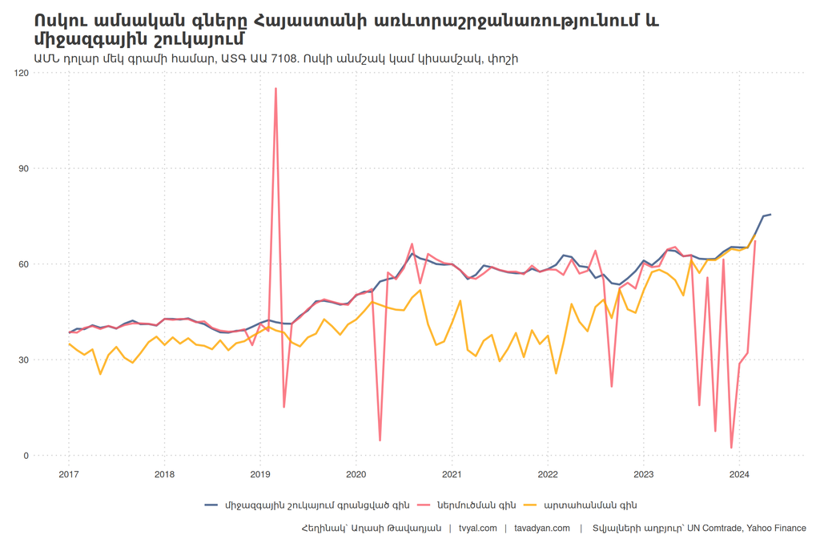

Գծապատկեր 5-ը ցույց է տալիս այս վերլուծության արդյունքները՝ բացահայտելով մի շարք ուշագրավ օրինաչափություններ և անոմալիաներ.

1. Համապատասխանություն միջազգային գներին: Մինչև 2023 թվականի օգոստոսը ոսկու ներմուծման գինը հիմնականում հետևում էր միջազգային շուկայական միտումներին: Այս կոռելյացիան ակնկալվում է գործող շուկայում և ենթադրում է, որ Հայաստանի ոսկու ներմուծումը հիմնականում համապատասխանում էր համաշխարհային գնահատումներին այս ժամանակահատվածում:
2. Համաշխարհային ոսկու գնի աճ: Գծապատկերը ցույց է տալիս ոսկու գնի զգալի աճ վերջին տարվա ընթացքում: Սա պայմանավորված է մի շարք գործոններով, ներառյալ ԱՄՆ դոլարի դեմ այլընտրանքային վճարման միջոցների որոնումը և ԲՐԻԿՍ երկրների կողմից ոսկու օգտագործումը որպես դոլարին այլընտրանք (Savage, 2023):
3. Ոսկու ներմուծման գնի անհամապատասխանություններ։ Պաշտոնական տվյալները ցույց են տալիս մի շարք անհանգստացնող անհամապատասխանություններ, հատկապես վերջին ամիսներին, երբ համաշխարհային շուկայում ոսլու գրամի գինը կազմում է մոտ 74 ԱՄՆ դոլար.
- 2023թ. օգոստոս՝ Հայաստան ոսկու ներմուծման գինն կազմել է մինչև 15,72 դոլար մեկ գրամի համար,
- 2023թ. հոկտեմբեր՝ կազմել է 7,62 դոլար մեկ գրամի համար,
- 2023թ. դեկտեմբեր՝ հասել է աննախադեպ ցածր մակարդակի՝ 2,41 դոլար մեկ գրամի համար,
- 2024թ. հունվար՝ կազմել է 28,73 դոլար մեկ գրամի համար։

Հատկապես ուշագրավ է 2023 թվականի դեկտեմբերի ցուցանիշը հատկապես ուշագրավ է: Պաշտոնական վիճակագրությունը ցույց է տալիս, որ այդ ամսվա ընթացքում Հայաստան է ներմուծվել 192 տոննա ոսկի՝ ընդամենը 2,41 ԱՄՆ դոլար արժողությամբ մեկ գրամի համար: Այս ծավալը բացառիկ մեծ է Հայաստանի չափերի երկրի համար, իսկ գինը շատ ավելի ցածր է, քան ոսկու ցանկացած ողջամիտ շուկայական գինը:

Այս անհամապատասխանությունները բարձրացնում են մի շարք կարևոր հարցեր.

1. Տվյալների ամբողջականություն. Արդյո՞ք այս ցուցանիշները կարող են վիճակագրական սխալների կամ սխալ հաշվետվության արդյունք լինել: Եթե այո, ապա ինչպիսի՞ն են հետևանքները Հայաստանի առևտրային վիճակագրության հուսալիության համար:
2. Գնահատման մեթոդներ. Արդյո՞ք կան նշանակալի փոփոխություններ ոսկու ներմուծման գնահատման եղանակներում: Ի՞նչ գործոններ կարող են բացատրել գների այսպիսի ծայրահեղ տատանումները:
3. Առևտրային պրակտիկա. Արդյո՞ք այս ցուցանիշներն արտացոլում են Հայաստանի ոսկու առևտրի պրակտիկայի կամ գործընկերների փոփոխությունները: Արդյո՞ք կան ոսկու հետ կապված նոր տեսակի ապրանքներ, որոնք ներմուծվում են և կարող են բացատրել գնային անոմալիաները:
4. Կարգավորիչ վերահսկողություն. Ի՞նչ դեր են խաղում Հայաստանի մաքսային և ֆինանսական կարգավորողները այս գործարքների վերահսկման գործում: Արդյո՞ք կան համարժեք մեխանիզմներ՝ ապահովելու ճշգրիտ հաշվետվությունն ու գնահատումը:
5. Տնտեսական հետևանքներ. Ինչպե՞ս են այս անհամապատասխանություններն ազդում Հայաստանի առևտրային հաշվեկշռի և ընդհանուր տնտեսական ցուցանիշների վրա: Ինչպիսի՞ն են հնարավոր հետևանքները տնտեսական քաղաքականության և միջազգային առևտրային հարաբերությունների համար:
6. Թափանցիկության խնդիրներ. Հաշվի առնելով ոսկու ռազմավարական կարևորությունը միջազգային ֆինանսներում, ինչպիսի՞ քայլեր կարելի է ձեռնարկել Հայաստանի ոսկու առևտրի հաշվետվության թափանցիկությունը բարձրացնելու համար:

### Եզրակացություն

Ռուսաստանի և Հայաստանի ներգրավմամբ ոսկու առևտրի օրինաչափությունների կտրուկ փոփոխությունը բարձրացնում է բազմաթիվ հարցեր այս գործարքների բնույթի և հետևանքների վերաբերյալ: Թեև պաշտոնապես գրանցված են որպես Հայաստանից արտահանում, այս ոսկու հոսքերը հիմնականում Ռուսաստանի ոսկու վերաարտահանումն են դեպի այլ երկրներ, մասնավորապես՝ Արաբական Միացյալ Էմիրություններ և Չինաստան:

Այս երևույթը նշանակալի հետևանքներ ունի Հայաստանի տնտեսական ցուցանիշների և միջազգային առևտրային ցանցերում նրա դիրքի ըմբռնման վրա: Արտահանման կենտրոնացումը մեկ, բարձր արժեք ունեցող ապրանքի վրա ներկայացնում է թե՛ հնարավորություններ, թե՛ ռիսկեր Հայաստանի տնտեսական ապագայի համար:

Քանի որ Հայաստանի դերը համաշխարհային ոսկու առևտրում շարունակում է զարգանալ, կարևոր է հետևել, թե ինչպես է դա ազդում երկրի ավելի լայն տնտեսական ցուցանիշների և միջազգային ֆինանսական հարաբերությունների վրա: Հաղորդված գների և ծավալների ծայրահեղ տատանումները ոչ միայն մտահոգություններ են առաջացնում տվյալների ճշգրտության վերաբերյալ, այլև նշանակալի հետևանքներ ունեն տնտեսական վերլուծության, քաղաքականության մշակման և միջազգային առևտրային հարաբերությունների համար:

### Մեթոդաբանություն

Ռուսաստանի ոսկու արտահանման վերջին միտումները վերլուծելիս տվյալների սահմանափակումները հաղթահարելու համար մենք կիրառում ենք «հայելային վիճակագրություն» կամ «հակադարձ վիճակագրություն» կոչվող մեթոդը: Այս մոտեցումը լայնորեն օգտագործվում է միջազգային կազմակերպությունների և հետազոտողների կողմից, երբ արտահանման ուղղակի տվյալները հասանելի կամ հուսալի չեն:

ՄԱԿ-ի վիճակագրական բաժանմունքը հայելային վիճակագրությունը սահմանում է որպես «գործընկեր երկրի ներմուծման (կամ արտահանման) տվյալների օգտագործում՝ տվյալ երկրի արտահանման (կամ ներմուծման) տվյալները ստանալու համար» (Միավորված ազգերի կազմակերպություն, 2011): Այս մեթոդը հատկապես օգտակար է առևտրային հոսքերը գնահատելու համար, երբ մի երկիր չի հաղորդում իր տվյալները, ինչպես Ռուսաստանի դեպքում է 2022 թվականից ի վեր:

Մեր մեթոդաբանությունը ներառում է.

- Յուրաքանչյուր երկրի ուղղակի հաշվետվության վերջին հասանելի ժամանակաշրջանի որոշում:
- Մինչև այդ ժամանակաշրջանը սկզբնական արտահանման տվյալների օգտագործում:
- Հետագա արտահանման տվյալների գնահատում՝ օգտագործելով գործընկեր երկրների ներմուծման հաշվետվությունները:

Այս մոտեցումը համահունչ է Արժույթի միջազգային հիմնադրամի (ԱՄՀ) առաջարկություններին՝ առևտրային վիճակագրության մեջ անհամաչափությունները կարգավորելու համար (ԱՄՀ, 2022) և հավանության է արժանացել Համաշխարհային բանկի կողմից՝ միջազգային առևտրի վերլուծության մեջ տվյալների բացերը լրացնելու համար (Համշխարհային բանկ, 2021):

Կարևոր է նշել, որ թեև հայելային վիճակագրությունը տալիս է արժեքավոր գնահատականներ, այն զերծ չէ սահմանափակումներից: Անհամապատասխանություններ կարող են առաջանալ երկրների միջև գնահատման մեթոդների, ժամկետների և դասակարգման պրակտիկայի տարբերությունների պատճառով (ՏՀԶԿ, 2023):

### Գրականության ցանկ

- Pop, V, and Fleming, S. and Politi, P. (2022, April 6). Weaponisation of finance: how the west unleashed ‘shock and awe’ on Russia. Financial Times. https://www.ft.com/content/5b397d6b-bde4-4a8c-b9a4-080485d6c64a
- Chandran, R. (2023, August 24). What is a BRICS currency and is the U.S. dollar in trouble? Reuters. https://www.reuters.com/markets/currencies/what-is-brics-currency-could-one-be-adopted-2023-08-23/
- International Monetary Fund. (2022). Balance of Payments and International Investment Position Manual. https://www.imf.org/-/media/Files/Publications/balance-of-payments-statistics/ABPEA2022001.ashx
- OECD. (2023). The Bilateral Trade Database by Industry and End-Use (BTDIxE). https://www.oecd.org/sti/ind/BTDIxE_2023_metadata.pdf
- United Nations. (2011). International Merchandise Trade Statistics: Concepts and Definitions 2010. https://www.un.org/en/development/desa/publications/international-merchandise-trade-statistics-concepts-and-definitions-2010-imts-2010.html
- World Bank. (2021). World Integrated Trade Solution (WITS) - User Manual. https://wits.worldbank.org/data/public/WITS_User_Manual.pdf
- World Gold Council. (2024). Gold Demand Trends Full Year and Q4 2023. https://www.gold.org/goldhub/research/gold-demand-trends/gold-demand-trends-full-year-2023

Եթե հնարավոր է, խնդրում եմ այս նյութը ուղարկել նաև այն մարդկանց, ում այն կարծում եք կարող է հետաքրքրել:

**ԱՅՍ ՀՈԴՎԱԾԻ ՀՂՈՒՄԸ**

*Թավադյան, Աղ․Ա․ (2024)․ Հայաստան` ռուսական ոսկու հանգրվան․ 2024-ին ռուսական ոսկու արտահանման 88 տոկոսն անցել է Հայաստանով [Armenia: Russia’s Gold Hub - In 2024, 88 percent of Russian gold exports passed through Armenia]․ Tvyal.com հարթակ [Tvyal.com platform], 5-07-2024․ https://www.tvyal.com/newsletter/2024/2024_07_05*

**Արգելվում է այս հարթակի նյութերը արտատպել առանց հղում կատարելու։**

* Այս և մեր բոլոր այլ վերլուծությունների տվյալները վերցված են պաշտոնական աղբյուրներից։ Հաշվարկները ամբողջությամբ հասանելի են github-ում, դրանք կարելի է ստուգել` այցելելով [github-ի](https://github.com/tavad/tvyal_newsletter/blob/main/2024/) մեր էջը, որտեղ տրված են տվյալները, հաշվարկների և գծապատկերների կոդը։

# ՀԱՄԱԳՈՐԾԱԿՑՈՒԹՅՈՒՆ

## Եթե ուզում եք ձեր տվյլներից օգուտ քաղել AI գործիքներով` ԴԻՄԵՔ ՄԵԶ

### Մենք առաջարկում ենք

- Extensive databases for finding both international and local leads
- Exclusive reports on the Future of the Armenian Economy
- Work and browser automation to streamline operations and reduce staffing needs
- AI models for forecasting growth and optimizing various aspects of your business
- Advanced dashboarding and BI solutions
- Algorithmic trading

### Let’s Put Your Data to Work!

### ՄԻԱՑԵՔ ՄԵՐ ԹԻՄԻՆ

> Ձեզ կարող են հետաքրքրել նաև մեր նախորդ հոդվածները.
> - [🚀♻🟨 Ոսկու տենդ. Հայաստանի արտահանման կեսը վերաարտահանում է](https://www.tvyal.com/newsletter/2024/2024_04_12)։
> - [🤒🟨♻️ Ոսկու տենդի շարունակություն. Հայաստանի արտահանման 75%-ը ոսկի և ադամանդ է](https://www.tvyal.com/newsletter/2024/2024_05_11)։

## English Summary

### 🇷🇺💰🇦🇲 Armenia: Russia’s Gold Hub - In 2024 88 percent of Russian gold exports passed through Armenia

In recent years, the global gold trade has undergone significant changes, with Armenia emerging as a key player in the redistribution of Russian gold exports. Following sanctions imposed on Russia in 2022, Armenia has become the primary destination for Russian gold, with 88.4% of Russia’s gold exports passing through Armenia in the first quarter of 2024. This shift has led to a dramatic increase in Armenia’s overall export figures, with gold re-exports accounting for approximately 76% of Armenia’s total exports in early 2024. The surge in gold trade has masked weaknesses in other sectors of Armenia’s economy, as exports of traditional goods have declined.

The analysis also reveals significant discrepancies in Armenia’s gold trade data, particularly in recent months. Notably, in December 2023, official statistics indicate that 192 tons of gold entered Armenia at an unprecedented low price of $2.41 per gram, far below any reasonable market rate. These anomalies raise critical questions about data integrity, valuation methods, trade practices, regulatory oversight, and the broader economic implications for Armenia. As Armenia’s role in the global gold trade continues to evolve, it will be crucial to monitor how this impacts the country’s economic indicators and international financial relationships, while addressing the need for improved data transparency and further investigation into these trade patterns.

Այս վերլուծությունը առկա է նաև [մեր կայքէջում](https://www.tvyal.com/newsletter/2024/2024_07_05), այս վերլուծության կոդը և տվյալները դրված են նաև [Github-ում](https://github.com/tavad/tvyal_newsletter)։

Հարգանքներով,  
Աղասի Թավադյան  
05.07.2024  
[tvyal.com](https://www.tvyal.com/)  
[tavadyan.com](https://www.tavadyan.com/)

[Was this email forwarded to you? Subscribe here.](https://www.tvyal.com/subscribe)

[Բաժանորդագրվեք](https://www.tvyal.com/subscribe)

**Ուշադրություն. Ձեր էլ.փոստը մեյլլիսթի մեջ է, որի միջոցով ես կիսվում եմ շաբաթական նյութեր, որոնք հիմնականում ներկայացնում են Հայաստանի տնտեսությունը: Նյութերը ներառում են գծապատկերներ, [տվյալների բազաներ](https://github.com/tavad/tvyal_newsletter), տեսանյութեր, հոդվածներ, [առցանց վահանակներ](https://www.tvyal.com/projects), տնտեսական գործիքներ, կանխատեսումներ և հաշվետվություններ: Եթե ցանկանում եք չեղարկել բաժանորդագրությունը, խնդրում եմ տեղեկացրեք ինձ, և ես կհեռացնեմ ձեր էլ. փոստը ցուցակից: Գրեք նաև եթե ունեք մենկնաբանություններ:**

**Important! Your email is part of the mailing list where I share weekly materials primarily focused on the Armenian economy. These materials encompass charts, [databases](https://github.com/tavad/tvyal_newsletter), videos, articles, [online dashboards](https://www.tvyal.com/projects), economic tools, forecasts, and reports. If you wish to unsubscribe, please let me know, and I will remove your email from the list. Please share your comments as well․**